# Sensitivity Analysis Latin Hypercube

Jared and Ata

# Assignment

With a new group: Sensitivity Analysis

Often when we are estimating vegetation or crop water use we need to know the atmospheric conductance - which is essentially how easily water diffuses into the air and depends largely on windspeed (you get more evaporation in windier conditions) Atmospheric conductance is also influenced by the vegetation itself and the turbulence it creates

I’ve provided a function to compute atmospheric conductance $C_{at}$ (how easily vapor diffuses from vegetation surfaces)

**The function *Catm.R* is provided**

So that you know what it does - here’s some background on the function
$$C_{at} = \frac{v_m}{6.25*{ln(\frac{z_m-z_d}{z_0})}^2}$$
$$z_d = k_d*h$$
$$z_0 = k_0*h$$

$z_m$ is the height at which windspeed is measured - must be higher than the vegetation (cm), it is usually measured 200 cm above the vegetation

$h$ is vegetation height (cm)

$v$ is windspeed (cm/s)

Typical values if $k_d$ and $k_o$ are 0.7 and 0.1 respectively (so use those as defaults)

**Your task**

For a given forest, you will perform a sensitivity analysis of model predictions of conductance Consider the sensitivity of your estimate to uncertainty in the following parameters and inputs

- $height$
- $k_d$
- $k_0$
- $v$

Windspeeds $v$ are normally distributed with a mean of 250 cm/s with a standard deviation of 30 cm/s

For vegetation height assume that height is somewhere between 9.5 and 10.5 m (but any value in that range is equally likely)

For the $k_d$ and $k_0$ parameters you can assume that they are normally distributed with standard deviation of 1% of their default values

1. Use the Latin hypercube approach to generate parameter values for the 4 parameters

```r
source("D:/UCSB/EDS_ 230/atmospheric_conductance_model/Catm.R")

# Define parameters names
pnames = c("height", "k_d", "k_o", "v")

#number of parameters
npar = length(pnames)

#number of samples
nsample = 100

parm_quant = randomLHS(nsample, npar)
colnames(parm_quant) = pnames


#we now have a matrix of parameter values with column names
parm = as.data.frame(matrix(nrow = nrow(parm_quant),
                            ncol = ncol(parm_quant)))
colnames(parm) = pnames



# now it's in the dataframe form, but with na values we will fill with our distribution

# height parameter has a uniform distribution from 9.5 to 10.5 meters
#setup pvar to 1%
pvar = 0.01


parm[, "height"] = qnorm(parm_quant[,"height"],
                         mean = 9.5,
                         sd= 10.5)

# k_d parameter has a mean of 0.7 and standard deviation is 1% of that default value

parm[,"k_d"] = qnorm(parm_quant[,"k_d"],
                     mean=0.7,
                     sd=0.01)

# k_0 parameter has a mean of 0.1 and standard deviation is 1% of that default value
parm[,"k_o"] = qunif(parm_quant[,"k_o"],
                     min=0.1,
                     max=0.1)

# Windspeeds 'v' are normally distributed with a mean of 250 cm/s with a standard deviation of 30 cm/s
parm[, "v"] = qnorm(parm_quant[,"v"],
                    mean = 250,
                    sd= 30)

# see if it looks right
parm_df <- data.frame(parm)

summary(parm_df)
```

```
##      height             k_d              k_o            v
##  Min.   :-16.803   Min.   :0.6725   Min.   :0.1   Min.   :177.8
##  1st Qu.:  2.592   1st Qu.:0.6933   1st Qu.:0.1   1st Qu.:230.3
##  Median :  9.443   Median :0.6999   Median :0.1   Median :249.8
##  Mean   :  9.505   Mean   :0.7000   Mean   :0.1   Mean   :250.0
##  3rd Qu.: 16.501   3rd Qu.:0.7065   3rd Qu.:0.1   3rd Qu.:270.2
##  Max.   : 38.613   Max.   :0.7274   Max.   :0.1   Max.   :326.9
```

2. Run the atmospheric conductance model for these parameters

```r
# Run the model for the differents parameters
atmospheric <- pmap( parm_df,Catm)

#check the results, is a list

head(atmospheric)
```

```
## [[1]]
## [1] 1437.701
##
## [[2]]
## [1] 0
##
## [[3]]
## [1] 0
##
## [[4]]
## [1] 1981.415
##
## [[5]]
## [1] 0
##
## [[6]]
## [1] 984.1715
```

```r
#Change to a dataframe

atmospheric_df <- data.frame(catm = unlist(atmospheric))

head(atmospheric_df)
```

```
##        catm
## 1 1437.7011
## 2    0.0000
## 3    0.0000
## 4 1981.4145
## 5    0.0000
## 6  984.1715
```

3. Plot conductance estimates in a way that accounts for parameter uncertainty

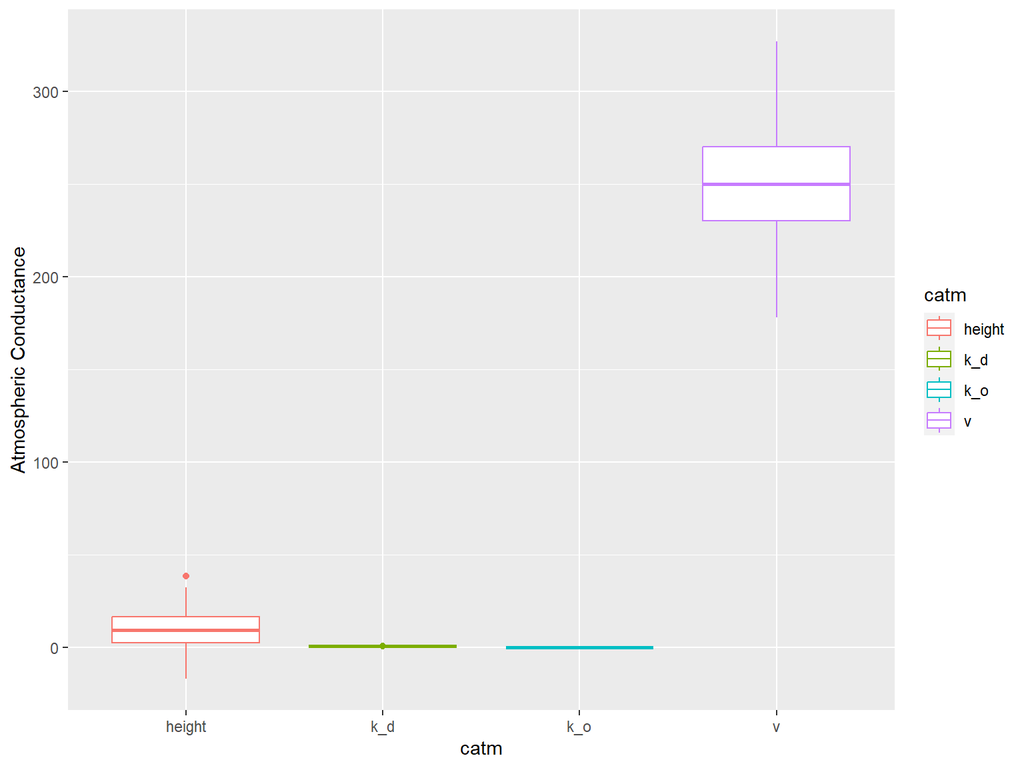

```r
# add uncertainty bounds on our estimates
atmospheric_all <- cbind(atmospheric_df, parm_df)


tmp = atmospheric_all|> gather(value = "value", key = "catm")
ggplot(tmp, aes(catm, value, col=catm))+geom_boxplot()+
  labs(y="Atmospheric Conductance")
```

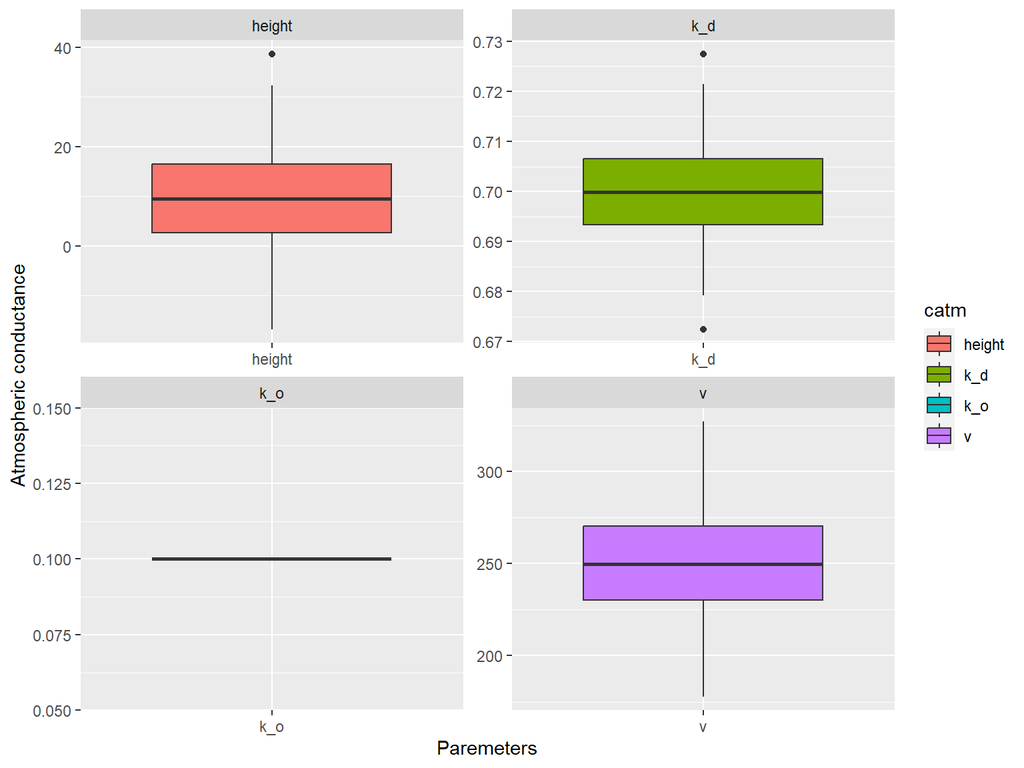

```r
# note that you don't see the ranges because of the scale (min yield anomoly much smaller than max) - here's a more informative way to graph
ggplot(tmp, aes(catm, value, fill = catm)) +
  geom_boxplot() +
  labs(y = "Atmospheric conductance",
       x = "Paremeters") +
  facet_wrap(~ catm, scales= "free")
```

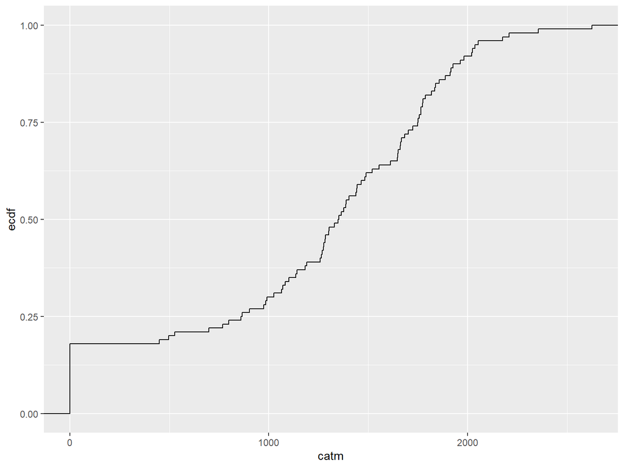

```r
# cumulative distribution
atmospheric_all$catm <- unlist(atmospheric_all$catm)
ggplot(atmospheric_all, aes(catm)) + stat_ecdf()
```

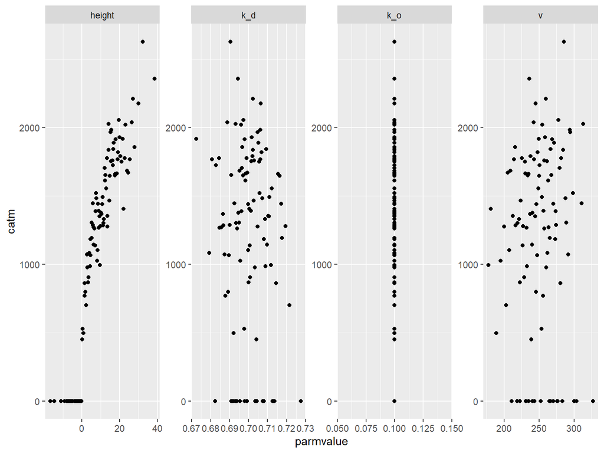

```r
# plot parameter sensitivity
# a bit tricky but nice way to make it easy to plot all parameters against all values

gathered_df = atmospheric_all%>% gather(height, k_d, k_o, v, key="parm", value="parmvalue")
ggplot(gathered_df, aes(parmvalue, catm))+geom_point()+facet_wrap(~parm, scales="free", ncol=5)
```

4. Plot conductance estimates against each of your parameters

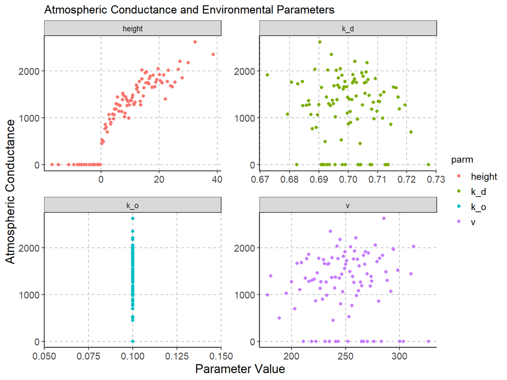

```r
# pivot longer for all atmospheric parameters
tmp1 = atmospheric_all |>gather(catm, value= "atm_value", key= "atm_con")

tmp2 = tmp1 |> gather(-atm_value, -atm_con, key= "parm", value = "parm_value")


# Create the plot
ggplot(tmp2, aes(parm_value, atm_value, color = parm)) +
  geom_point() +
  facet_wrap(~parm, scales = "free") +
  theme_bw() +
  theme(
    axis.line = element_line(),
    panel.grid.major = element_line(colour = "gray", linetype = "dashed"),
    panel.grid.minor = element_blank(),
    panel.border = element_blank(),
    axis.text = element_text(size = 11),
    axis.title = element_text(size = 14),
    legend.title = element_text(size = 11),
    legend.text = element_text(size = 11),
    legend.position = "right",
    panel.spacing = unit(1, "lines")
  ) +
  labs(
    x = "Parameter Value",
    y = "Atmospheric Conductance",
    title = "Atmospheric Conductance and Environmental Parameters"
  )
```

5. Estimate the Partial Rank Correlation Coefficients

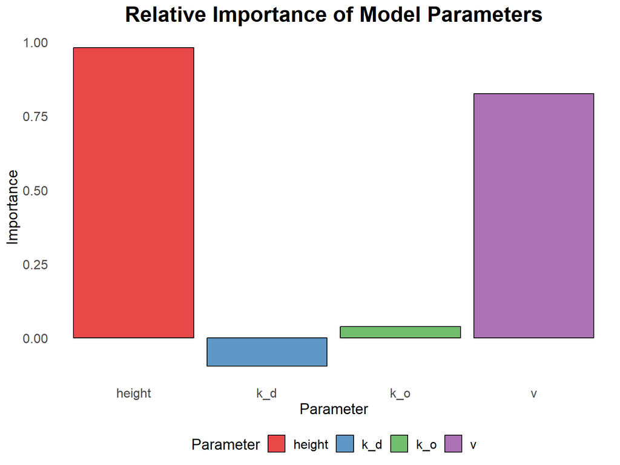

```r
senresult_rank = pcc(parm_df, atmospheric_df, rank = TRUE)
results <- as.data.frame(senresult_rank$PRCC)

# extract the values from the  result

height <- results$original[1]
k_d <- results$original[2]
k_o <- results$original[3]
v <- results$original[4]

# create the data frame
result_df <- data.frame(parameter = c( "height", "k_d", "k_o","v"),
                 importance = c( height, k_d, k_o, v))


# Create the ggplot object
ggplot(result_df, aes(x = parameter, y = importance, fill = parameter)) +
  geom_bar(stat = "identity", alpha = 0.8, color = "black", size = 0.5) +
  scale_fill_brewer(palette = "Set1") +
  labs(title = "Relative Importance of Model Parameters",
       x = "Parameter",
       y = "Importance",
       fill = "Parameter") +
  theme_minimal() +
  theme(plot.title = element_text(size = 20, face = "bold", hjust = 0.5),
        axis.title = element_text(size = 14),
        axis.text = element_text(size = 12),
        legend.title = element_text(size = 14),
        legend.text = element_text(size = 12),
        legend.position = "bottom",
        panel.grid.major = element_blank(),
        panel.grid.minor = element_blank(),
        panel.background = element_blank())
```

Submit the Rmarkdown (or link to git repo) as usual

**Grading Rubric**

- Generation of parameter values using latin hypercube sampling (10pts)
- Running model for the parameters (10pts)
- Graph of conductance uncertainty
  - meaningful graph (5pts)
  - graphing style (axis labels, legibility) (5 pts)
- Graph of conductance against parameter values
  - meaningful graph (5pts)
  - graphing style (axis labels, legibility) (5 pts)
- Correct Rank Correlation Coefficients (10 pts)
- Discussion (10pts)
  - suggestion for how to reduce uncertainty that follows from your analysis (5pts)
  - idea about how uncertainty might impact estimate of plant water use under climate change (5pts)